# Explore_bikeshare_data

### Explore Bike Share Data

For this project, your goal is to ask and answer three questions about the available bikeshare data from Washington, Chicago, and New York. This notebook can be submitted directly through the workspace when you are confident in your results.

```r
library(ggplot2)
```

```r
ny = read.csv('new_york_city.csv')
wash = read.csv('washington.csv')
chi = read.csv('chicago.csv')
```

```r
head(ny)
```

| X | Start.Time | End.Time | Trip.Duration | Start.Station | End.Station | User.Type | Gender | Birth.Year |
| --- | --- | --- | --- | --- | --- | --- | --- | --- |
| 5688089 | 2017-06-11 14:55:05 | 2017-06-11 15:08:21 | 795 | Suffolk St & Stanton St | W Broadway & Spring St | Subscriber | Male | 1998 |
| 4096714 | 2017-05-11 15:30:11 | 2017-05-11 15:41:43 | 692 | Lexington Ave & E 63 St | 1 Ave & E 78 St | Subscriber | Male | 1981 |
| 2173887 | 2017-03-29 13:26:26 | 2017-03-29 13:48:31 | 1325 | 1 Pl & Clinton St | Henry St & Degraw St | Subscriber | Male | 1987 |
| 3945638 | 2017-05-08 19:47:18 | 2017-05-08 19:59:01 | 703 | Barrow St & Hudson St | W 20 St & 8 Ave | Subscriber | Female | 1986 |
| 6208972 | 2017-06-21 07:49:16 | 2017-06-21 07:54:46 | 329 | 1 Ave & E 44 St | E 53 St & 3 Ave | Subscriber | Male | 1992 |
| 1285652 | 2017-02-22 18:55:24 | 2017-02-22 19:12:03 | 998 | State St & Smith St | Bond St & Fulton St | Subscriber | Male | 1986 |

```r
head(wash)
```

| X | Start.Time | End.Time | Trip.Duration | Start.Station | End.Station | User.Type |
| --- | --- | --- | --- | --- | --- | --- |
| 1621326 | 2017-06-21 08:36:34 | 2017-06-21 08:44:43 | 489.066 | 14th & Belmont St NW | 15th & K St NW | Subscriber |
| 482740 | 2017-03-11 10:40:00 | 2017-03-11 10:46:00 | 402.549 | Yuma St & Tenley Circle NW | Connecticut Ave & Yuma St NW | Subscriber |
| 1330037 | 2017-05-30 01:02:59 | 2017-05-30 01:13:37 | 637.251 | 17th St & Massachusetts Ave NW | 5th & K St NW | Subscriber |
| 665458 | 2017-04-02 07:48:35 | 2017-04-02 08:19:03 | 1827.341 | Constitution Ave & 2nd St NW/DOL | M St & Pennsylvania Ave NW | Customer |
| 1481135 | 2017-06-10 08:36:28 | 2017-06-10 09:02:17 | 1549.427 | Henry Bacon Dr & Lincoln Memorial Circle NW | Maine Ave & 7th St SW | Subscriber |
| 1148202 | 2017-05-14 07:18:18 | 2017-05-14 07:24:56 | 398.000 | 1st & K St SE | Eastern Market Metro / Pennsylvania Ave & 7th St SE | Subscriber |

```r
head(chi)
```

| X | Start.Time | End.Time | Trip.Duration | Start.Station | End.Station | User.Type | Gender | Birth.Year |
| --- | --- | --- | --- | --- | --- | --- | --- | --- |
| 1423854 | 2017-06-23 15:09:32 | 2017-06-23 15:14:53 | 321 | Wood St & Hubbard St | Damen Ave & Chicago Ave | Subscriber | Male | 1992 |
| 955915 | 2017-05-25 18:19:03 | 2017-05-25 18:45:53 | 1610 | Theater on the Lake | Sheffield Ave & Waveland Ave | Subscriber | Female | 1992 |
| 9031 | 2017-01-04 08:27:49 | 2017-01-04 08:34:45 | 416 | May St & Taylor St | Wood St & Taylor St | Subscriber | Male | 1981 |
| 304487 | 2017-03-06 13:49:38 | 2017-03-06 13:55:28 | 350 | Christiana Ave & Lawrence Ave | St. Louis Ave & Balmoral Ave | Subscriber | Male | 1986 |
| 45207 | 2017-01-17 14:53:07 | 2017-01-17 15:02:01 | 534 | Clark St & Randolph St | Desplaines St & Jackson Blvd | Subscriber | Male | 1975 |
| 1473887 | 2017-06-26 09:01:20 | 2017-06-26 09:11:06 | 586 | Clinton St & Washington Blvd | Canal St & Taylor St | Subscriber | Male | 1990 |

# Question 1

**What are the counts of each user type?**

```r
## Function to get counts of each user type
## Convert to table to get counts and convert back to dataframe
## remove blank space user types
usertype_counts = function(dataset, column) {
  column_counts = table(dataset[[column]])
  column_counts = as.data.frame(column_counts)
  colnames(column_counts) = c(column, "Counts")
  column_counts = subset(column_counts, column_counts[[column]] != "")
  return(column_counts)
}
```

### New York

```r
unique(ny$User.Type)
```

1. Subscriber

2. Customer

**Levels**:**

1. ''

2. 'Customer'

3. 'Subscriber'

```r
## Use usertype_counts function
usertype_ny = usertype_counts(ny, "User.Type")
usertype_ny
```

|  | User.Type | Counts |
| --- | --- | --- |
| 2 | Customer | 5558 |
| 3 | Subscriber | 49093 |

```r
ggplot(data = usertype_ny, aes(x = User.Type, y = Counts, fill = User.Type)) +
  geom_bar(stat = "identity") +
  labs(title = "User Type Counts",
       x = "User Types",
       y = "Counts")
```

[output not shown]

### Washington

```r
unique(wash$User.Type)
```

1. Subscriber

2. Customer

**Levels**:**

1. ''

2. 'Customer'

3. 'Subscriber'

```r
## Use usertype_counts function
usertype_wash = usertype_counts(ny, "User.Type")
```

```r
ggplot(data = usertype_wash, aes(x = User.Type, y = Counts, fill = User.Type)) +
  geom_bar(stat = "identity") +
  labs(title = "User Type Counts",
       x = "User Types",
       y = "Counts")
```

[output not shown]

### Chicago

```r
unique(chi$User.Type)
```

1. Subscriber

2. Customer

**Levels**:**

1. ''

2. 'Customer'

3. 'Subscriber'

```r
## Use usertype_counts function
usertype_chi = usertype_counts(ny, "User.Type")
```

```r
ggplot(data = usertype_chi, aes(x = User.Type, y = Counts, fill = User.Type)) +
  geom_bar(stat = "identity") +
  labs(title = "User Type Counts",
       x = "User Types",
       y = "Counts")
```

[output not shown]

### User Type Counts:

**New York:** 5558 Customers and 49093 Subscribers

## Question 2

**What is the most common start station?**

### New York

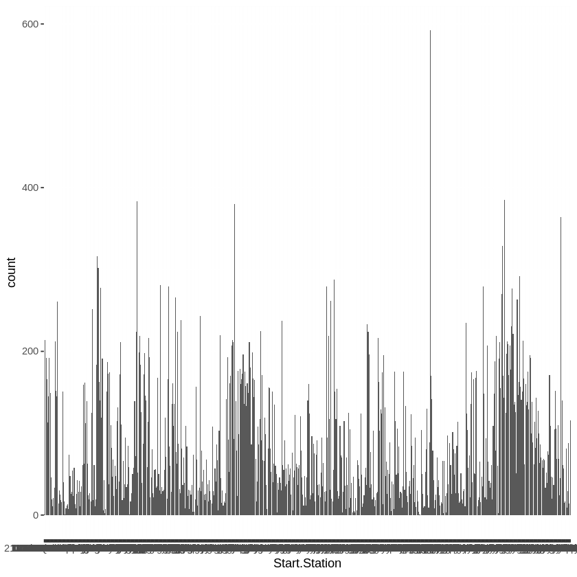

```r
ggplot(aes(x=Start.Station), data=ny) +
  geom_bar()
```

- Few counts are above 300, filter by 300 to make dataset more manageable

```r
ss_ny = table(ny$Start.Station)
ss_ny = as.data.frame(ss_ny)
colnames(ss_ny) <- c("Starting.Point", "Counts")
ss_ny = subset(ss_ny, Counts > 300)
```

```r
ss_ny
```

|  | Starting.Point | Counts |
| --- | --- | --- |
| 65 | 8 Ave & W 31 St | 316 |
| 66 | 8 Ave & W 33 St | 302 |
| 113 | Broadway & E 22 St | 383 |
| 231 | E 17 St & Broadway | 380 |
| 467 | Pershing Square North | 592 |
| 554 | W 20 St & 11 Ave | 329 |
| 557 | W 21 St & 6 Ave | 385 |
| 625 | West St & Chambers St | 364 |

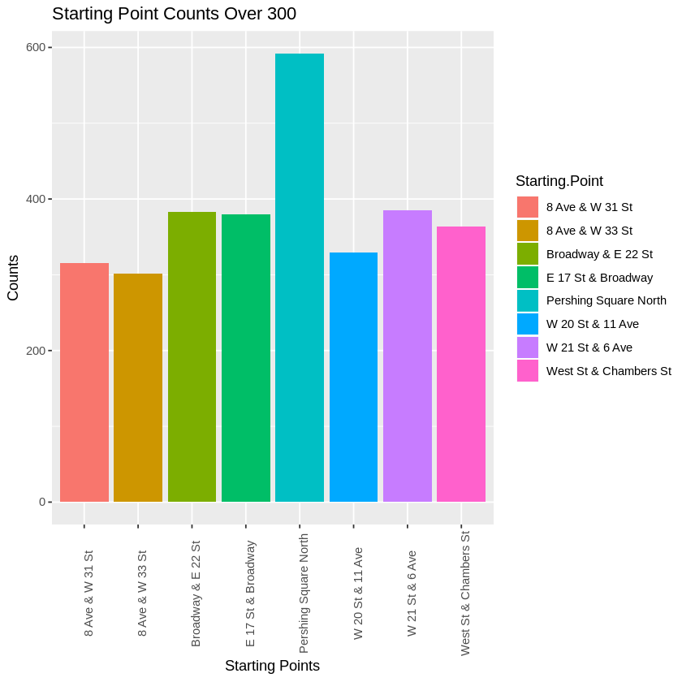

```r
ggplot(data = ss_ny, aes(x = Starting.Point, y = Counts, fill = Starting.Point)) +
  geom_bar(stat = "identity") +
  labs(title = "Starting Point Counts Over 300",
       y = "Counts",
      x= "Starting Points") +
  theme(axis.text.x = element_text(angle = 90))
```

### Washington

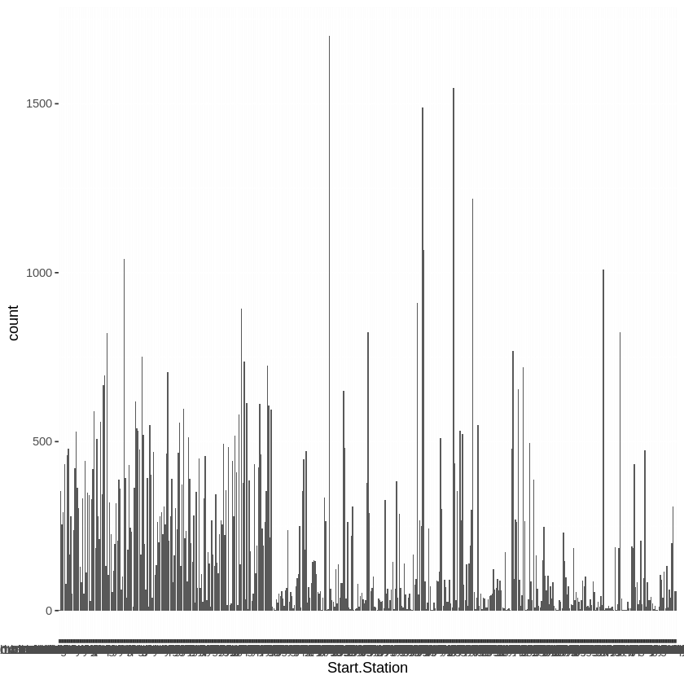

```r
ggplot(aes(x=Start.Station), data=wash) +
  geom_bar()
```

- Few counts are above 1000, filter by 1000 to make dataset more manageable

```r
ss_wash = table(wash$Start.Station)
ss_wash = as.data.frame(ss_wash)
colnames(ss_wash) <- c("Starting.Point", "Counts")
ss_wash = subset(ss_wash, Counts > 1000)
```

```r
ss_wash
```

|  | Starting.Point | Counts |
| --- | --- | --- |
| 51 | 15th & P St NW | 1040 |
| 210 | Columbus Circle / Union Station | 1700 |
| 282 | Jefferson Dr & 14th St SW | 1488 |
| 283 | Jefferson Memorial | 1068 |
| 306 | Lincoln Memorial | 1546 |
| 321 | Massachusetts Ave & Dupont Circle NW | 1219 |
| 422 | Smithsonian-National Mall / Jefferson Dr & 12th St SW | 1010 |

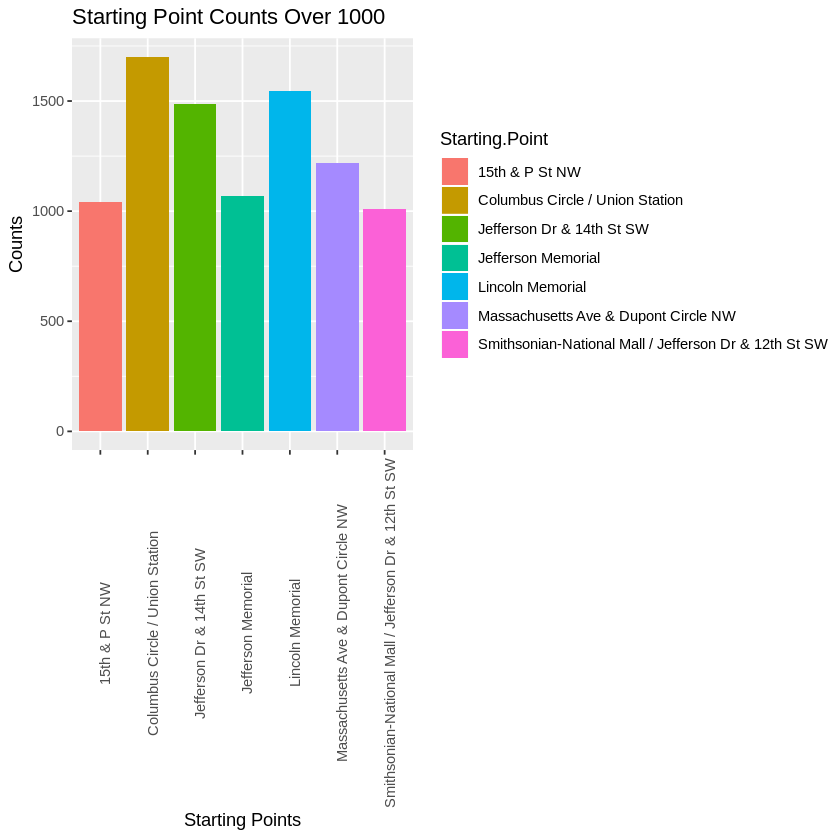

```r
ggplot(data = ss_wash, aes(x = Starting.Point, y = Counts, fill = Starting.Point)) +
  geom_bar(stat = "identity") +
  labs(title = "Starting Point Counts Over 1000",
       y = "Counts",
      x= "Starting Points") +
  theme(axis.text.x = element_text(angle = 90))
```

### Chicago

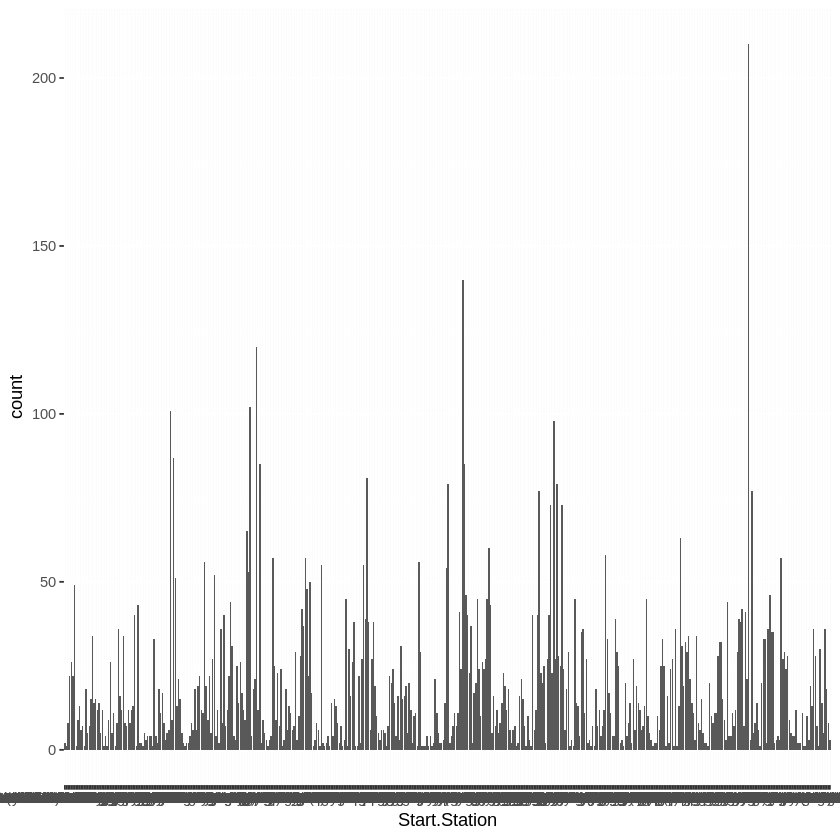

```r
ggplot(aes(x=Start.Station), data=chi) +
  geom_bar()
```

- Few counts are above 100, filter by 100 to make dataset more manageable

```r
ss_chi = table(chi$Start.Station)
ss_chi = as.data.frame(ss_chi)
colnames(ss_chi) <- c("Starting.Point", "Counts")
ss_chi = subset(ss_chi, Counts > 100)
```

```r
ss_chi
```

|  | Starting.Point | Counts |
| --- | --- | --- |
| 66 | Canal St & Adams St | 101 |
| 115 | Clinton St & Madison St | 102 |
| 119 | Clinton St & Washington Blvd | 120 |
| 246 | Lake Shore Dr & Monroe St | 140 |
| 422 | Streeter Dr & Grand Ave | 210 |

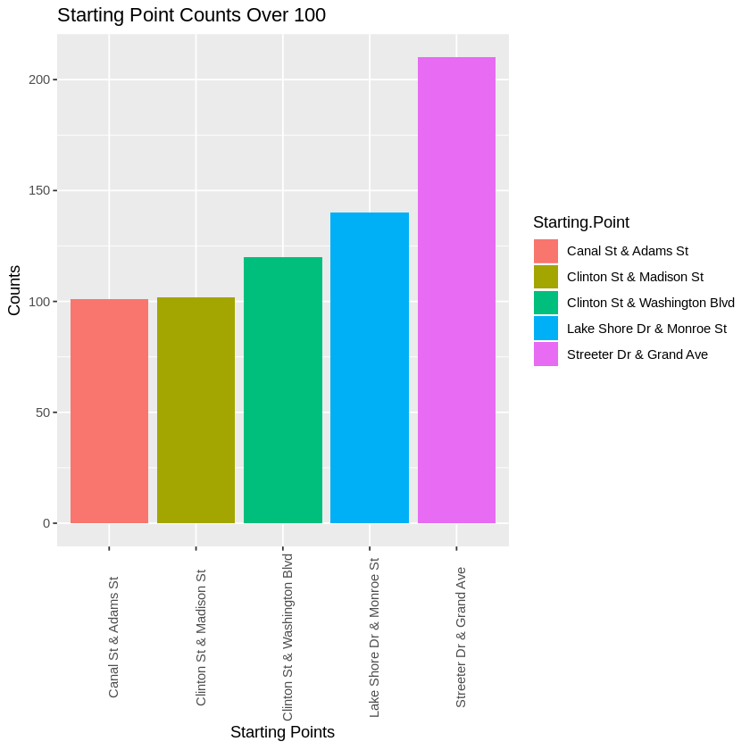

```r
ggplot(data = ss_chi, aes(x = Starting.Point, y = Counts, fill = Starting.Point)) +
  geom_bar(stat = "identity") +
  labs(title = "Starting Point Counts Over 100",
       y = "Counts",
      x= "Starting Points") +
  theme(axis.text.x = element_text(angle = 90))
```

### Most Common Starting Point:

**New York:** Perishing Square North

**Chicago:** Streeter Dr & Grand Ave

# Question 3

**What is the average travel time by user type?**

### New York

```r
ad_ny = aggregate(Trip.Duration ~ User.Type, data = ny, FUN = mean)
colnames(ad_ny) <- c("User.Type", "Average.Trip.Duration")
ad_ny = subset(ad_ny, User.Type != "")
```

```r
print(ad_ny)
```

```
   User.Type Average.Trip.Duration
2   Customer             2193.0759
3 Subscriber              755.3829
```

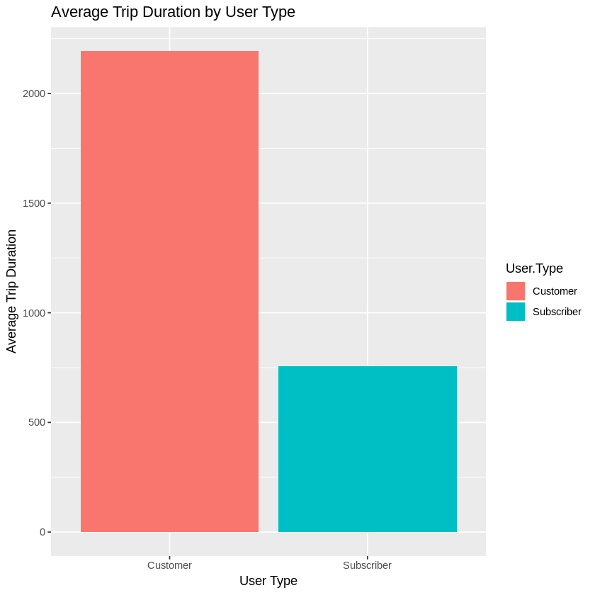

```r
ggplot(data = ad_ny, aes(x = User.Type, y = Average.Trip.Duration, fill = User.Type)) +
  geom_bar(stat = "identity") +
  labs(title = "Average Trip Duration by User Type",
       x = "User Type",
       y = "Average Trip Duration")
```

### Washington

```r
ad_wash = aggregate(Trip.Duration ~ User.Type, data = wash, FUN = mean)
colnames(ad_wash) <- c("User.Type", "Average.Trip.Duration")
ad_wash = subset(ad_wash, User.Type != "")
```

```r
print(ad_wash)
```

```
   User.Type Average.Trip.Duration
1   Customer              2634.429
2 Subscriber               733.326
```

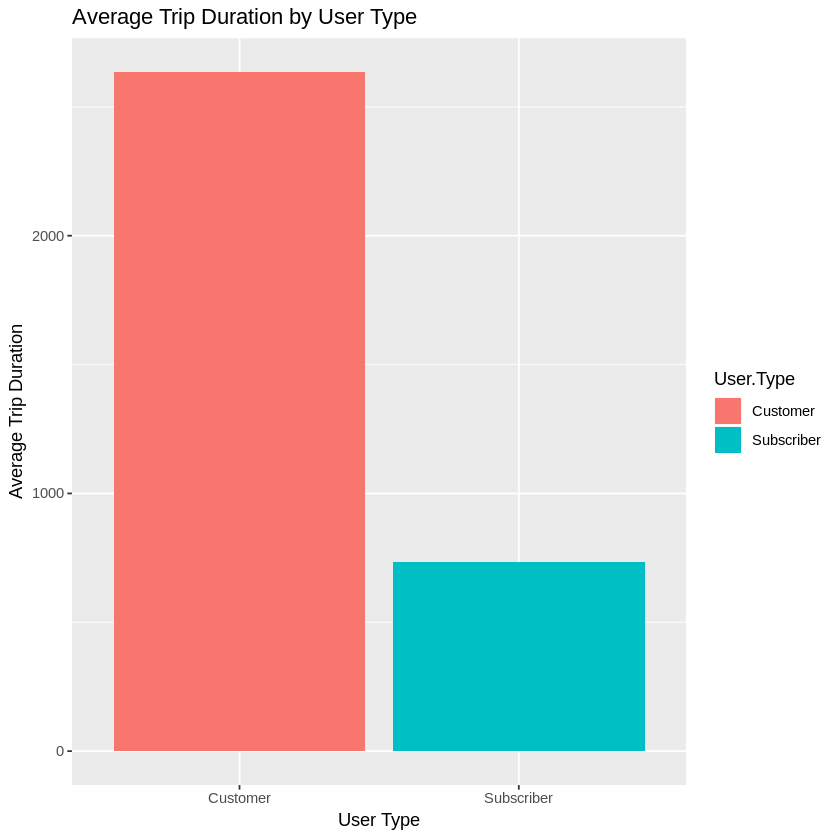

```r
ggplot(data = ad_wash, aes(x = User.Type, y = Average.Trip.Duration, fill = User.Type)) +
  geom_bar(stat = "identity") +
  labs(title = "Average Trip Duration by User Type",
       x = "User Type",
       y = "Average Trip Duration")
```

### Chicago

```r
ad_chi = aggregate(chi$Trip.Duration, by = list(chi$User.Type), FUN = mean)
colnames(ad_chi) <- c("User.Type", "Average.Trip.Duration")
ad_chi = subset(ad_chi, User.Type != "")
```

```r
print(ad_chi)
```

```
   User.Type Average.Trip.Duration
2   Customer              1929.977
3 Subscriber               685.027
```

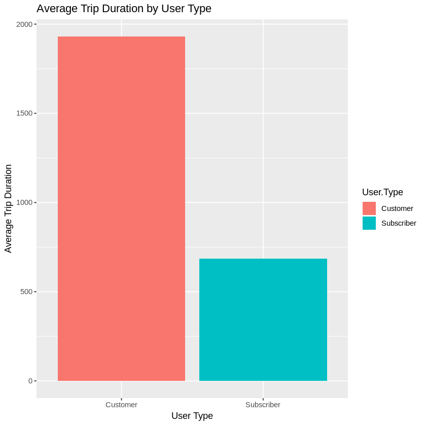

```r
ggplot(data = ad_chi, aes(x = User.Type, y = Average.Trip.Duration, fill = User.Type)) +
  geom_bar(stat = "identity") +
  labs(title = "Average Trip Duration by User Type",
       x = "User Type",
       y = "Average Trip Duration")
```

### Average Trip Duration by User Type:

**New York:**

- Customer: 2193.1 seconds/36.6 minutes
- Subscriber: 755.4 seconds/12.6 minutes

- Customer: 2634.4 seconds/43.9 minutes
- Subscriber: 733.3 seconds/12.2 minutes

- Customer: 1930.0 seconds/32.2 minutes
- Subscriber: 685.0/11.4 minutes

**In all three cities, customers on average took longer trips than subscribers.**